# Social Equity, Access and the New York School System

Kunal Kerai

August 29, 2018

## Background and Problem Statement

PASSNYC – a not-for-profit organization that facilitates a collective impact– is dedicated to broadening educational opportunities for New York City’s talented and underserved students. New York City is home to some of the most impressive educational institutions in the world, yet in recent years, the City’s specialized high schools - institutions with historically transformative impact on student outcomes - have seen a shift toward more homogeneous student body demographics.

PASSNYC uses public data to identify students within New York City’s under-performing school districts and, through consulting and collaboration with partners, aims to increase the diversity of students taking the Specialized High School Admissions Test (SHSAT). By focusing efforts in under-performing areas that are historically underrepresented in SHSAT registration, we will help pave the path to specialized high schools for a more diverse group of students.

With limited time and resources, PASSNYC must be strategic in systemically improving the diversity pipeline and social mobility of certain disadvantaged groups into the specialized schools. The main question to be answered is where will PASSNYC’s investment produce the greatest ROI for the services they offer (after school programs, test preparation, mentoring, or resources for parents)?

## Data Dictionary

- school: school name
- DBN: State Education Department Code
- district
- lat: lattitude coordinates of school
- long: longitude coordinates of school
- address: full address of school
- City
- zip
- commSchool: Is the school a community school (Y/N)?
- eni income: (%temp housing) + (% HRA eligible x 0.5) + (% free lunch eligible x 0.5). The higher the index, the higher the need.
- pctELL: percent of English Language Learners
- Race Percentages: percent of school that identifies as a certain race.
  - pctAsian
  - pctBlack
  - pctHispanic
  - pctBlackHispanic: percent of Black students + percent of Hispanic students
  - pctWhite: White
- Attendance
  - pctAttend: total number of days attended by all students / total number of days on register for all students
  - pctAbsentChronic: percent of students missing 10% of school days - or 18 days+ per year in a 180-day school year
- Psychosocial Ratings
  - pctRigor: How well the curriculum and instruction engage students, build critical-thinking skills, and are aligned to the Common Core
  - ratingRigor: How well the curriculum and instruction engage students, build critical-thinking skills, and are aligned to the Common Core
  - pctCollab: How well teachers participate in opportunities to develop, grow, and contribute to the continuous improvement of the school community
  - ratingCollab: How well teachers participate in opportunities to develop, grow, and contribute to the continuous improvement of the school community
  - pctSupp: How well the school establishes a culture where students feel safe, challenged to grow, and supported to meet high expectations
  - ratingSupp: How well the school establishes a culture where students feel safe, challenged to grow, and supported to meet high expectations
  - pctLeader: How well school leadership inspires the school community with a clear instructional vision and effectively distributes leadership to realize this vision
  - ratingLeader: How well school leadership inspires the school community with a clear instructional vision and effectively distributes leadership to realize this vision
  - pctCommunity: How well the school forms effective partnerships with families to improve the school
  - ratingCommunity: How well the school forms effective partnerships with families to improve the school
  - pctTrust: Whether the relationships between administrators, educators, students, and families are based on trust and respect
  - ratingTrust: Whether the relationships between administrators, educators, students, and families are based on trust and respect
- Average School Scores for English (ELA) and Math sections
  - avgELA
  - avgMath
  - academicScore (sum of ELA and Math)
- Students and test statistics for District 5/6
  - enroll: number of students enrolled in the school
  - registered: number of students who registered for SHSAT
  - took: number of students who took the SHSAT
  - regPct: registered/enroll
  - tookPct: took/enroll
  - yield: took/registered
- Numeric values for psychosocial categories (0= NA, 1= Not Meeting Expectations, 2= Approaching Expectations, 3= Meeting Expectations, 4= Exceeeding Expectations))
  - quantCollab
  - quantSupp
  - quantRigor
  - quantLeader
  - quantCommunity
  - quantTrust
- Number of URM students who received the highest score possible for the English and Math sections by race:
  - elaBlack
  - elaHispanic
  - mathBlack
  - mathHispanic

## Data Cleaning

### Loading Libraries and Data

Let’s load some libraries we will use.

```r
library(tidyverse)
library(ggplot2)
library(cluster)
library(scatterplot3d)
library(digest)
library(corrplot)
library(ggmap)
library(factoextra)
library(data.table)
library(DT)
library(GGally)
library(caret)
library(cluster)
library(randomForest)
library(mlbench)
library(ggmap)
```

Let’s load our data from the table:

```r
reg <- read_csv("D5 SHSAT Registrations and Testers.csv")
school <- read_csv("2016 School Explorer.csv")
```

Before we proceed, let’s take a look at the initial data.

```r
str(reg)
```

```
## Classes 'tbl_df', 'tbl' and 'data.frame':    140 obs. of  7 variables:
##  $ DBN                                            : chr  "05M046" "05M046" "05M046" "05M046" ...
##  $ School name                                    : chr  "P.S. 046 Arthur Tappan" "P.S. 046 Arthur Tappan" "P.S. 046 Arthur Tappan" "P.S. 046 Arthur Tappan" ...
##  $ Year of SHST                                   : int  2013 2014 2015 2016 2013 2014 2015 2016 2013 2014 ...
##  $ Grade level                                    : int  8 8 8 8 8 8 8 8 8 8 ...
##  $ Enrollment on 10/31                            : int  91 95 73 56 62 62 62 55 84 55 ...
##  $ Number of students who registered for the SHSAT: int  31 26 21 20 31 25 12 16 58 23 ...
##  $ Number of students who took the SHSAT          : int  14 7 10 8 14 13 5 5 14 12 ...
##  - attr(*, "spec")=List of 2
##   ..$ cols   :List of 7
##   .. ..$ DBN                                            : list()
##   .. .. ..- attr(*, "class")= chr  "collector_character" "collector"
##   .. ..$ School name                                    : list()
##   .. .. ..- attr(*, "class")= chr  "collector_character" "collector"
##   .. ..$ Year of SHST                                   : list()
##   .. .. ..- attr(*, "class")= chr  "collector_integer" "collector"
##   .. ..$ Grade level                                    : list()
##   .. .. ..- attr(*, "class")= chr  "collector_integer" "collector"
##   .. ..$ Enrollment on 10/31                            : list()
##   .. .. ..- attr(*, "class")= chr  "collector_integer" "collector"
##   .. ..$ Number of students who registered for the SHSAT: list()
##   .. .. ..- attr(*, "class")= chr  "collector_integer" "collector"
##   .. ..$ Number of students who took the SHSAT          : list()
##   .. .. ..- attr(*, "class")= chr  "collector_integer" "collector"
##   ..$ default: list()
##   .. ..- attr(*, "class")= chr  "collector_guess" "collector"
##   ..- attr(*, "class")= chr "col_spec"
```

```r
str(school)
```

```
## Classes 'tbl_df', 'tbl' and 'data.frame':    1272 obs. of  161 variables:
##  $ Adjusted Grade                                    : chr  NA NA NA NA ...
##  $ New?                                              : chr  NA NA NA NA ...
##  $ Other Location Code in LCGMS                      : chr  NA NA NA NA ...
##  $ School Name                                       : chr  "P.S. 015 ROBERTO CLEMENTE" "P.S. 019 ASHER LEVY" "P.S. 020 ANNA SILVER" "P.S. 034 FRANKLIN D. ROOSEVELT" ...
##  $ SED Code                                          : num  3.1e+11 3.1e+11 3.1e+11 3.1e+11 3.1e+11 ...
##  $ Location Code                                     : chr  "01M015" "01M019" "01M020" "01M034" ...
##  $ District                                          : int  1 1 1 1 1 1 1 1 1 1 ...
##  $ Latitude                                          : num  40.7 40.7 40.7 40.7 40.7 ...
##  $ Longitude                                         : num  -74 -74 -74 -74 -74 ...
##  $ Address (Full)                                    : chr  "333 E 4TH ST NEW YORK, NY 10009" "185 1ST AVE NEW YORK, NY 10003" "166 ESSEX ST NEW YORK, NY 10002" "730 E 12TH ST NEW YORK, NY 10009" ...
##  $ City                                              : chr  "NEW YORK" "NEW YORK" "NEW YORK" "NEW YORK" ...
##  $ Zip                                               : int  10009 10003 10002 10009 10009 10009 10002 10002 10002 10002 ...
##  $ Grades                                            : chr  "PK,0K,01,02,03,04,05" "PK,0K,01,02,03,04,05" "PK,0K,01,02,03,04,05" "PK,0K,01,02,03,04,05,06,07,08" ...
##  $ Grade Low                                         : chr  "PK" "PK" "PK" "PK" ...
##  $ Grade High                                        : chr  "05" "05" "05" "08" ...
##  $ Community School?                                 : chr  "Yes" "No" "No" "No" ...
##  $ Economic Need Index                               : chr  "0.919" "0.641" "0.744" "0.86" ...
##  $ School Income Estimate                            : chr  "$31,141.72" "$56,462.88" "$44,342.61" "$31,454.00" ...
##  $ Percent ELL                                       : chr  "9%" "5%" "15%" "7%" ...
##  $ Percent Asian                                     : chr  "5%" "10%" "35%" "5%" ...
##  $ Percent Black                                     : chr  "32%" "20%" "8%" "29%" ...
##  $ Percent Hispanic                                  : chr  "60%" "63%" "49%" "63%" ...
##  $ Percent Black / Hispanic                          : chr  "92%" "83%" "57%" "92%" ...
##  $ Percent White                                     : chr  "1%" "6%" "4%" "4%" ...
##  $ Student Attendance Rate                           : chr  "94%" "92%" "94%" "92%" ...
##  $ Percent of Students Chronically Absent            : chr  "18%" "30%" "20%" "28%" ...
##  $ Rigorous Instruction %                            : chr  "89%" "96%" "87%" "85%" ...
##  $ Rigorous Instruction Rating                       : chr  "Meeting Target" "N/A" "Meeting Target" "Approaching Target" ...
##  $ Collaborative Teachers %                          : chr  "94%" "96%" "77%" "78%" ...
##  $ Collaborative Teachers Rating                     : chr  "Meeting Target" "N/A" "Meeting Target" "Meeting Target" ...
##  $ Supportive Environment %                          : chr  "86%" "97%" "82%" "82%" ...
##  $ Supportive Environment Rating                     : chr  "Exceeding Target" "N/A" "Approaching Target" "Meeting Target" ...
##  $ Effective School Leadership %                     : chr  "91%" "90%" "61%" "73%" ...
##  $ Effective School Leadership Rating                : chr  "Exceeding Target" "Exceeding Target" "Not Meeting Target" "Approaching Target" ...
##  $ Strong Family-Community Ties %                    : chr  "85%" "86%" "80%" "89%" ...
##  $ Strong Family-Community Ties Rating               : chr  "Meeting Target" "Meeting Target" "Approaching Target" "Meeting Target" ...
##  $ Trust %                                           : chr  "94%" "94%" "79%" "88%" ...
##  $ Trust Rating                                      : chr  "Exceeding Target" "Meeting Target" "Not Meeting Target" "Meeting Target" ...
##  $ Student Achievement Rating                        : chr  "Approaching Target" "Exceeding Target" "Approaching Target" "Exceeding Target" ...
```

[output cut: 250 more lines]

```
##   .. .. ..- attr(*, "class")= chr  "collector_integer" "collector"
##   .. ..$ Grade 5 Math 4s - Black or African American       : list()
##   .. .. ..- attr(*, "class")= chr  "collector_integer" "collector"
##   .. ..$ Grade 5 Math 4s - Hispanic or Latino              : list()
##   .. .. ..- attr(*, "class")= chr  "collector_integer" "collector"
##   .. ..$ Grade 5 Math 4s - Asian or Pacific Islander       : list()
##   .. .. ..- attr(*, "class")= chr  "collector_integer" "collector"
##   .. ..$ Grade 5 Math 4s - White                           : list()
##   .. .. ..- attr(*, "class")= chr  "collector_integer" "collector"
##   .. ..$ Grade 5 Math 4s - Multiracial                     : list()
##   .. .. ..- attr(*, "class")= chr  "collector_integer" "collector"
##   .. .. [list output truncated]
##   ..$ default: list()
##   .. ..- attr(*, "class")= chr  "collector_guess" "collector"
##   ..- attr(*, "class")= chr "col_spec"
```

Our data looks pretty clean by most standards, but there is work to be done for sure. For example, we’ll need to rename some of our variable names, join our two tables, etc. Let’s move forward with some cleaning.

## Exploratory Data Analysis

Before continuing, there are three things we need to consider when analyzing our data:

- PassNYC cares about increasing diversity; therefore need to look at low income, and underrepresented racial minorities (URM) students
- PassNYC wants to improve the situation through their offerings: after school programs, test preparation, mentoring, and resources for parents
- Success will be measured by how many student register then take the test, as well as the academic performance of the school as an indicator.

We consider a school to be economically stratified if its economic need as measured by the Economic Need Index1 is more than 10 percentage points from the citywide average. A school can be stratified in either direction - by serving more low-income or more high-income children. New York City reports that 70.6% of schools are economically stratified today.

### Demographics

```r
reg3<-gather(school_clean, race, percent, pctAsian:pctWhite, factor_key=TRUE)

head(reg3)
```

```
## # A tibble: 6 x 68
##   school DBN   district   lat  long address City    zip commSchool   eni
##   <chr>  <chr>    <int> <dbl> <dbl> <chr>   <chr> <int> <chr>      <dbl>
## 1 P.S. ~ 01M0~        1  40.7 -74.0 333 E ~ NEW ~ 10009 Yes        0.919
## 2 P.S. ~ 01M0~        1  40.7 -74.0 185 1S~ NEW ~ 10003 No         0.641
## 3 P.S. ~ 01M0~        1  40.7 -74.0 166 ES~ NEW ~ 10002 No         0.744
## 4 P.S. ~ 01M0~        1  40.7 -74.0 730 E ~ NEW ~ 10009 No         0.86
## 5 THE S~ 01M0~        1  40.7 -74.0 121 E ~ NEW ~ 10009 No         0.73
## 6 P.S. ~ 01M0~        1  40.7 -74.0 600 E ~ NEW ~ 10009 No         0.858
## # ... with 58 more variables: income <dbl>, pctELL <dbl>, pctAttend <dbl>,
## #   pctAbsentChronic <dbl>, pctRigor <dbl>, ratingRigor <chr>,
## #   pctCollab <dbl>, ratingCollab <chr>, pctSupp <dbl>, ratingSupp <chr>,
## #   pctLeader <dbl>, ratingLeader <chr>, pctCommunity <dbl>,
## #   ratingCommunity <chr>, pctTrust <dbl>, ratingTrust <chr>, `Student
## #   Achievement Rating` <chr>, avgELA <dbl>, avgMath <dbl>, elaAll <int>,
## #   elaAll4 <int>, elaBlack <int>, elaHispanic <int>, elaAsian <int>,
## #   elaWhite <int>, mathAll <int>, mathAll4 <int>, mathBlack <int>,
## #   mathHispanic <int>, mathAsian <int>, mathWhite <int>, enroll <dbl>,
## #   registered <dbl>, took <dbl>, regPct <dbl>, tookPct <dbl>,
## #   yield <dbl>, academicScore <dbl>, quantRigor <dbl>, quantCollab <dbl>,
## #   quantSupp <dbl>, quantLeader <dbl>, quantCommunity <dbl>,
## #   quantTrust <dbl>, pctELA4 <dbl>, pctELABlack <dbl>,
## #   pctELAHispanic <dbl>, pctELAAsian <dbl>, pctELAWhite <dbl>,
## #   pctMath4 <dbl>, pctMathBlack <dbl>, pctMathHispanic <dbl>,
## #   pctMathAsian <dbl>, pctMathWhite <dbl>, URM4 <int>,
## #   commSchoolBinary <dbl>, race <fct>, percent <dbl>
```

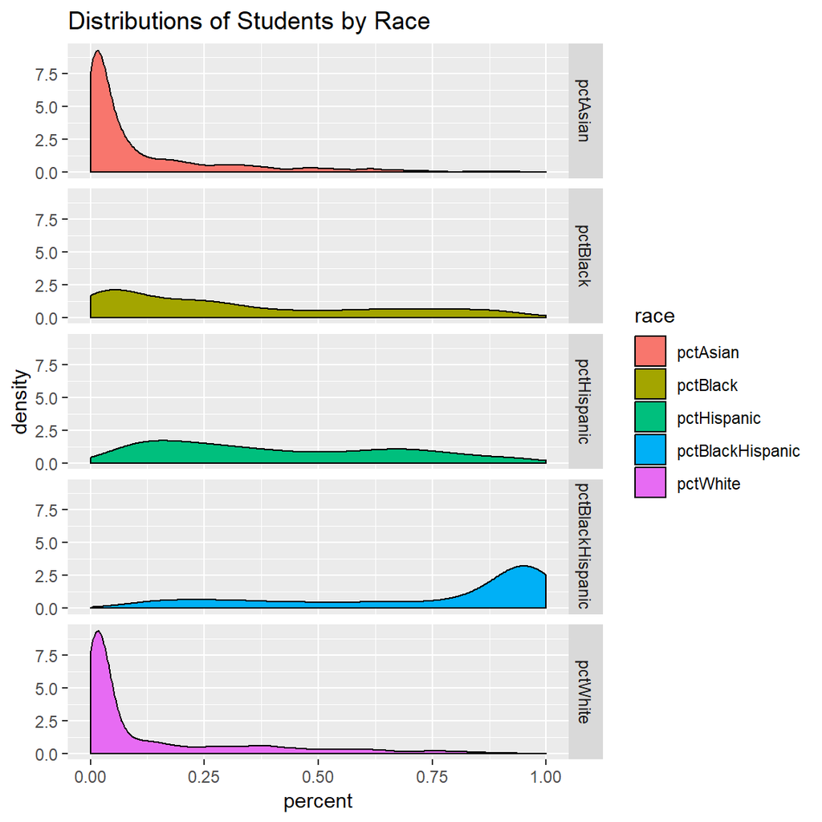

```r
#Racial Demographic Distribution
ggplot(reg3, aes(x = percent, fill = race)) +
  geom_density() +
  facet_grid(race ~ .) +
  labs(title="Distributions of Students by Race")
```

Most NY schools have a low White and Asian population, but a high URM population. Now where are they located?

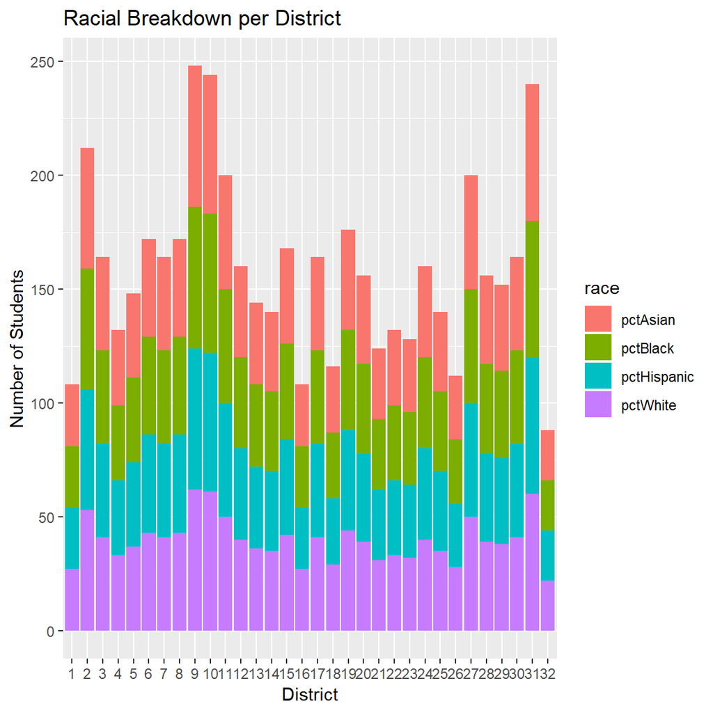

```r
toBeRemoved<-which(reg3$race=="pctBlackHispanic")
reg4 <-reg3[-toBeRemoved,]

ggplot(reg4, aes( x = as.factor(district), fill = race)) +
  geom_bar() +
  labs(title="Racial Breakdown per District",
       x= "District",
       y = "Number of Students")
```

From our Districts, we can see that most of our students come from Districts 9, 10, 31, 2, and 27.

[output not shown]

[output not shown]

From this exploratory plot, we’re seeing that race and income interact with each other in the form of stratification, so let’s take further look at the ENI of NYC:

[output not shown]

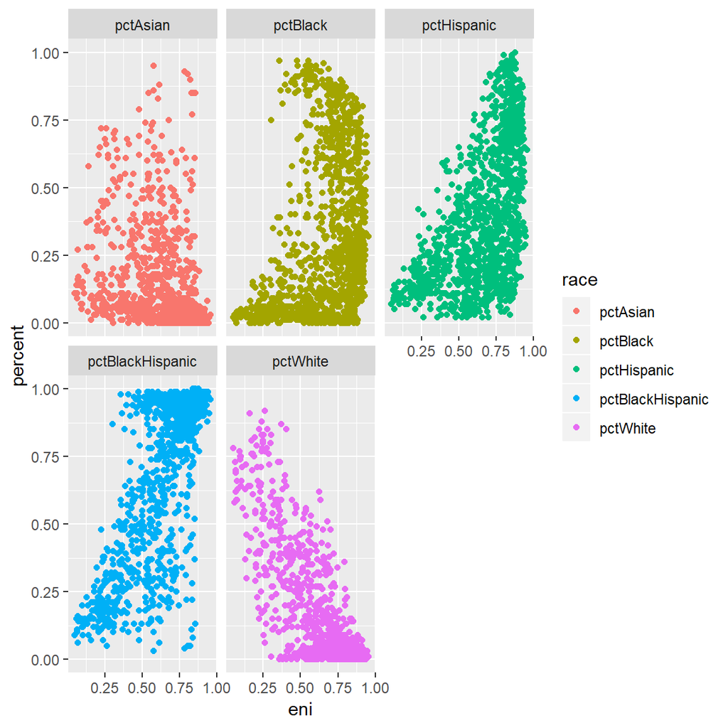

```r
ggplot(reg3, aes(x = eni, y = percent, col = race)) +
  geom_point() +
  facet_wrap(.~race)
```

```r
raceENI <- lm(eni~pctBlackHispanic, data = school_clean)
summary(raceENI)
```

```
##
## Call:
## lm(formula = eni ~ pctBlackHispanic, data = school_clean)
##
## Residuals:
##      Min       1Q   Median       3Q      Max
## -0.45278 -0.08124  0.01480  0.08578  0.53042
##
## Coefficients:
##                  Estimate Std. Error t value Pr(>|t|)
## (Intercept)       0.26611    0.01011   26.32   <2e-16 ***
## pctBlackHispanic  0.55578    0.01283   43.32   <2e-16 ***
## ---
## Signif. codes:  0 '***' 0.001 '**' 0.01 '*' 0.05 '.' 0.1 ' ' 1
##
## Residual standard error: 0.1333 on 1246 degrees of freedom
##   (25 observations deleted due to missingness)
## Multiple R-squared:  0.601,  Adjusted R-squared:  0.6007
## F-statistic:  1877 on 1 and 1246 DF,  p-value: < 2.2e-16
```

## Academic Performance

Now let’s take a look at academic performance as it is the main thing we’re looking to improve for NYCPASS:

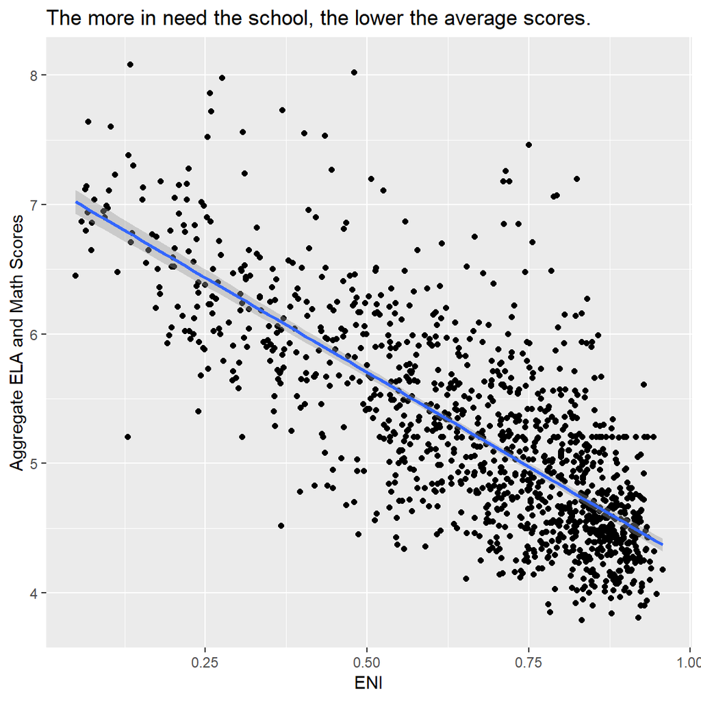

```r
ggplot(school_clean, aes(eni, academicScore)) +
  geom_point() +
  stat_smooth(method = "lm") +
  labs(title="The more in need the school, the lower the average scores.",
       x= "ENI",
       y="Aggregate ELA and Math Scores")
```

```r
scoreENImodel <- lm(academicScore ~ eni + pctBlackHispanic, data = school_clean)
summary(scoreENImodel)
```

```
##
## Call:
## lm(formula = academicScore ~ eni + pctBlackHispanic, data = school_clean)
##
## Residuals:
##      Min       1Q   Median       3Q      Max
## -1.49106 -0.31199 -0.07117  0.23773  2.64125
##
## Coefficients:
##                  Estimate Std. Error t value Pr(>|t|)
## (Intercept)       7.16953    0.04624  155.03   <2e-16 ***
## eni              -1.75005    0.10389  -16.84   <2e-16 ***
## pctBlackHispanic -1.08150    0.07448  -14.52   <2e-16 ***
## ---
## Signif. codes:  0 '***' 0.001 '**' 0.01 '*' 0.05 '.' 0.1 ' ' 1
##
## Residual standard error: 0.4888 on 1245 degrees of freedom
##   (25 observations deleted due to missingness)
## Multiple R-squared:  0.6376, Adjusted R-squared:  0.637
## F-statistic:  1095 on 2 and 1245 DF,  p-value: < 2.2e-16
```

Economic need is a strong predictor of how well a school will do and it makes sense– the higher the need students have, the lower the scores will be due to resource insecurity. As we’ve found out from before, ENI and race have a relatively strong correlation, but there must be schools that despite their high ENI, produce a high number of 4s.

## Examining Academic Performance

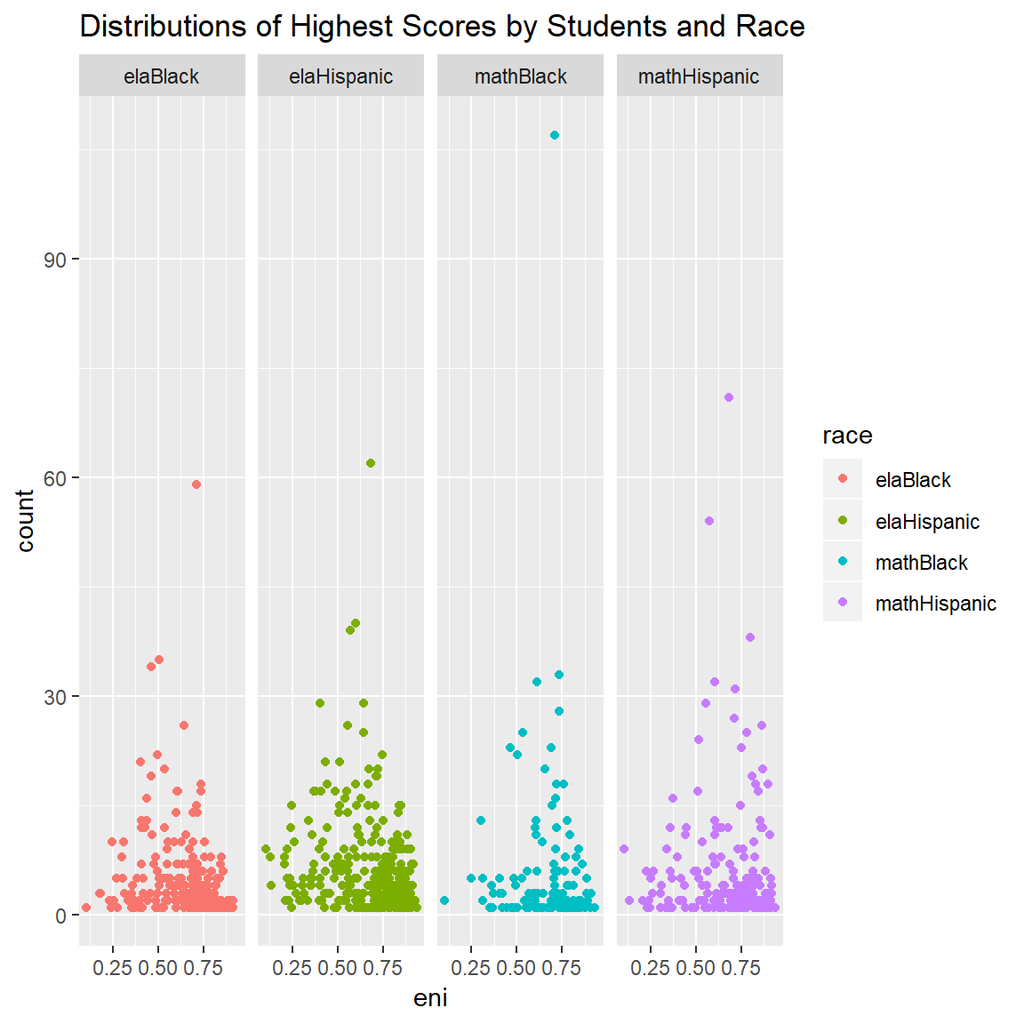

```r
reg2 <- gather(school_clean, race, count, c(elaBlack, elaHispanic, mathBlack, mathHispanic), factor_key=TRUE)
reg2 <- reg2 %>%
  filter(!is.na(count) & count>0)

reg2$countScale<- scale(reg2$count)

school_16<- reg2 %>%
  group_by(school)%>%
  filter(countScale>1)%>%
  summarise(count = sum(count))


#Racial Demographic Distribution
ggplot(reg2, aes(y = count, x = eni, col = race)) +
  geom_point() +
  facet_grid(. ~ race) +
  labs(title="Distributions of Highest Scores by Students and Race")
```

One way of understanding performance is examining the number of URM students receiving 4s for their exams, but not just any schools, why not target the highest schools? We target schools who fall 1 standard deviation above the mean (top 16% of schools) to produce a list of schools we can specifically target with NYCPASS’s programs to further bolster their numbers:

```r
school_16 <- school_16 %>%
  arrange(desc(count))
school_16
```

```
## # A tibble: 62 x 2
##    school                                             count
##    <chr>                                              <int>
##  1 SUCCESS ACADEMY CHARTER SCHOOL - HARLEM 1            212
##  2 I.S. 145 JOSEPH PULITZER                             133
##  3 I.S. 73 - THE FRANK SANSIVIERI INTERMEDIATE SCHOOL    93
##  4 M.S. 180 DR. DANIEL HALE WILLIAMS                     57
##  5 I.S. 227 LOUIS ARMSTRONG                              55
##  6 J.H.S. 383 PHILIPPA SCHUYLER                          55
##  7 P.S. 189 THE BILINGUAL CENTER                         51
##  8 I.S. 230                                              50
##  9 SCHOLARS' ACADEMY                                     50
## 10 ACHIEVEMENT FIRST BUSHWICK CHARTER SCHOOL             49
## # ... with 52 more rows
```

### Recommendation 1

[output not shown]

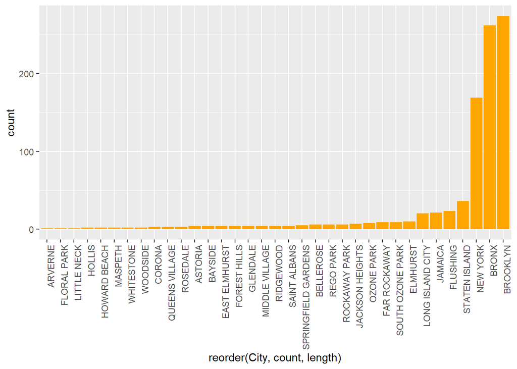

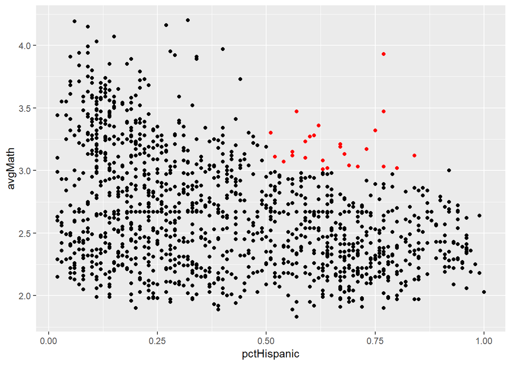

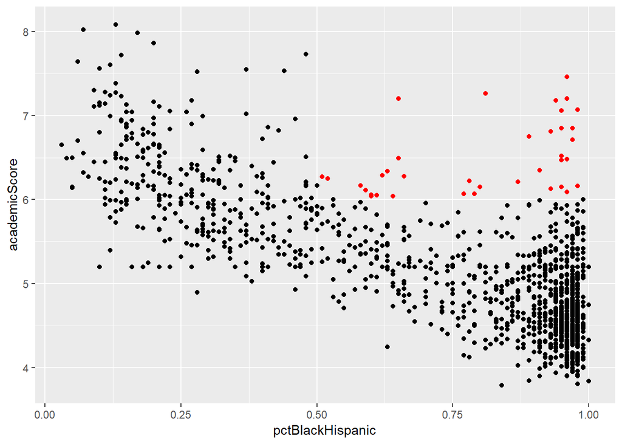

```
## # A tibble: 29 x 71
##    school DBN   district   lat  long address City    zip commSchool   eni
##    <chr>  <chr>    <int> <dbl> <dbl> <chr>   <chr> <int> <chr>      <dbl>
##  1 THE M~ 06M2~        6  40.8 -74.0 71-111~ NEW ~ 10027 No         0.724
##  2 P.S. ~ 08X3~        8  40.8 -73.8 2750 L~ BRONX 10465 No         0.388
##  3 P.S. ~ 15K1~       15  40.7 -74.0 825 4T~ BROO~ 11232 No         0.715
##  4 ROBER~ 24Q5~       24  40.7 -73.9 47-07 ~ LONG~ 11101 No         0.513
##  5 P.S. ~ 25Q1~       25  40.8 -73.8 128-02~ COLL~ 11356 No         0.454
##  6 P.S. ~ 27Q2~       27  40.7 -73.8 84-40 ~ RICH~ 11418 No         0.603
##  7 ALL C~ 32K5~       32  40.7 -73.9 321 PA~ BROO~ 11237 No         0.667
##  8 ACHIE~ 84K5~       32  40.7 -73.9 1300 G~ BROO~ 11237 No         0.718
##  9 CENTR~ 84Q0~       24  40.7 -73.9 55-30 ~ ELMH~ 11373 No         0.688
## 10 SOUTH~ 84X3~       12  40.8 -73.9 977 FO~ BRONX 10459 No         0.756
## # ... with 19 more rows, and 61 more variables: income <dbl>,
## #   pctELL <dbl>, pctAsian <dbl>, pctBlack <dbl>, pctHispanic <dbl>,
## #   pctBlackHispanic <dbl>, pctWhite <dbl>, pctAttend <dbl>,
## #   pctAbsentChronic <dbl>, pctRigor <dbl>, ratingRigor <chr>,
## #   pctCollab <dbl>, ratingCollab <chr>, pctSupp <dbl>, ratingSupp <chr>,
## #   pctLeader <dbl>, ratingLeader <chr>, pctCommunity <dbl>,
## #   ratingCommunity <chr>, pctTrust <dbl>, ratingTrust <chr>, `Student
## #   Achievement Rating` <chr>, avgELA <dbl>, avgMath <dbl>, elaAll <int>,
## #   elaAll4 <int>, elaBlack <int>, elaHispanic <int>, elaAsian <int>,
## #   elaWhite <int>, mathAll <int>, mathAll4 <int>, mathBlack <int>,
## #   mathHispanic <int>, mathAsian <int>, mathWhite <int>, enroll <dbl>,
## #   registered <dbl>, took <dbl>, regPct <dbl>, tookPct <dbl>,
## #   yield <dbl>, academicScore <dbl>, quantRigor <dbl>, quantCollab <dbl>,
## #   quantSupp <dbl>, quantLeader <dbl>, quantCommunity <dbl>,
## #   quantTrust <dbl>, pctELA4 <dbl>, pctELABlack <dbl>,
## #   pctELAHispanic <dbl>, pctELAAsian <dbl>, pctELAWhite <dbl>,
## #   pctMath4 <dbl>, pctMathBlack <dbl>, pctMathHispanic <dbl>,
## #   pctMathAsian <dbl>, pctMathWhite <dbl>, URM4 <int>,
## #   commSchoolBinary <dbl>
```

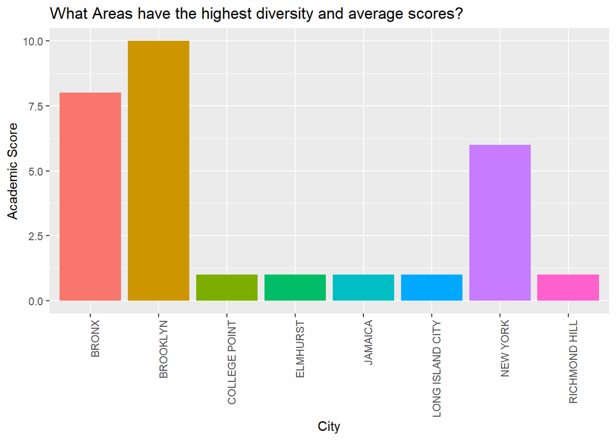

## Correlation Matrix

```
## # A tibble: 8 x 71
##   school DBN   district   lat  long address City    zip commSchool   eni
##   <chr>  <chr>    <int> <dbl> <dbl> <chr>   <chr> <int> <chr>      <dbl>
## 1 P.S. ~ 05M0~        5  40.8 -73.9 2987 F~ NEW ~ 10039 No         0.903
## 2 P.S. ~ 05M1~        5  40.8 -73.9 301 W ~ NEW ~ 10030 Yes        0.835
## 3 P.S. ~ 05M1~        5  40.8 -74.0 425 W ~ NEW ~ 10027 No         0.854
## 4 P.S. ~ 05M1~        5  40.8 -74.0 499 W ~ NEW ~ 10027 No         0.875
## 5 HARLE~ 84M2~        5  40.8 -73.9 245 W ~ NEW ~ 10027 No         0.768
## 6 KIPP ~ 84M3~        5  40.8 -74.0 625 W ~ NEW ~ 10027 No         0.798
## 7 HARLE~ 84M3~        5  40.8 -73.9 35 E 1~ NEW ~ 10035 No         0.757
## 8 SUCCE~ 84M3~        5  40.8 -73.9 144 E ~ NEW ~ 10035 No         0.734
## # ... with 61 more variables: income <dbl>, pctELL <dbl>, pctAsian <dbl>,
## #   pctBlack <dbl>, pctHispanic <dbl>, pctBlackHispanic <dbl>,
## #   pctWhite <dbl>, pctAttend <dbl>, pctAbsentChronic <dbl>,
## #   pctRigor <dbl>, ratingRigor <chr>, pctCollab <dbl>,
## #   ratingCollab <chr>, pctSupp <dbl>, ratingSupp <chr>, pctLeader <dbl>,
## #   ratingLeader <chr>, pctCommunity <dbl>, ratingCommunity <chr>,
## #   pctTrust <dbl>, ratingTrust <chr>, `Student Achievement Rating` <chr>,
## #   avgELA <dbl>, avgMath <dbl>, elaAll <int>, elaAll4 <int>,
## #   elaBlack <int>, elaHispanic <int>, elaAsian <int>, elaWhite <int>,
## #   mathAll <int>, mathAll4 <int>, mathBlack <int>, mathHispanic <int>,
## #   mathAsian <int>, mathWhite <int>, enroll <dbl>, registered <dbl>,
## #   took <dbl>, regPct <dbl>, tookPct <dbl>, yield <dbl>,
## #   academicScore <dbl>, quantRigor <dbl>, quantCollab <dbl>,
## #   quantSupp <dbl>, quantLeader <dbl>, quantCommunity <dbl>,
## #   quantTrust <dbl>, pctELA4 <dbl>, pctELABlack <dbl>,
## #   pctELAHispanic <dbl>, pctELAAsian <dbl>, pctELAWhite <dbl>,
## #   pctMath4 <dbl>, pctMathBlack <dbl>, pctMathHispanic <dbl>,
## #   pctMathAsian <dbl>, pctMathWhite <dbl>, URM4 <int>,
## #   commSchoolBinary <dbl>
```

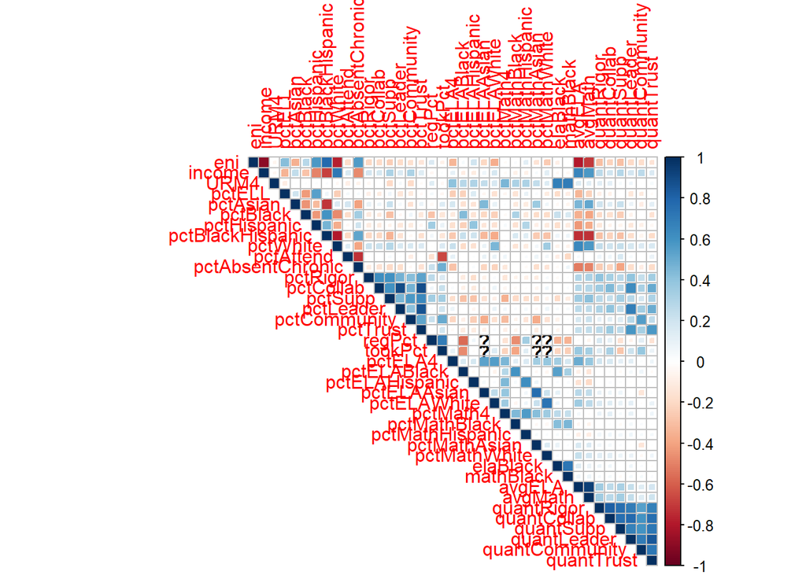

### Machine Learning

Let’s start with clustering. We can only use District 5 data, since they are the only schools reporting number of students who took the SHSAT. Note: this is such a small amount of data, we might have that our clusters have weak, or no structure but let’s try it out.

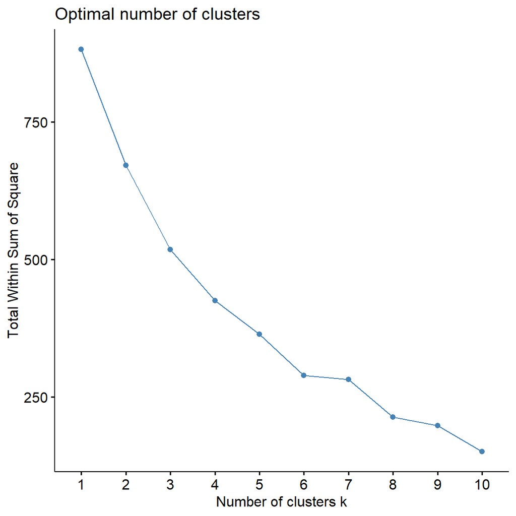

```r
num.school <- school_clean%>%
  filter(!is.na(took))%>%
  select(-income, -City, -address, -DBN, -registered, -yield, -took, -enroll,-regPct, -commSchool, -lat, -long, -zip, -district, -elaAsian, -mathAsian, -mathWhite, -pctELAAsian, -elaAsian, -pctMathAsian, -pctMathWhite, -(contains("rating")))

scaled.school<- (scale(num.school[,2:43]))


fviz_nbclust(scaled.school, kmeans, method = "wss")
```

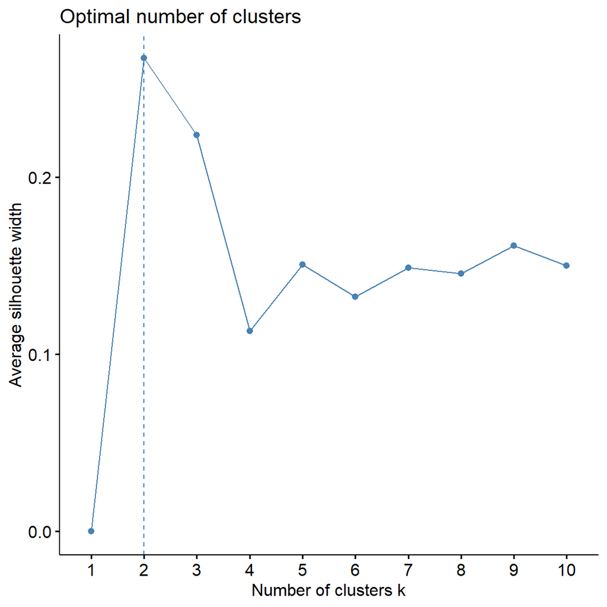

```r
fviz_nbclust(scaled.school, kmeans, method = "silhouette")
```

```r
final <- kmeans(scaled.school, 3, nstart = 25)
print(final)
```

```
## K-means clustering with 3 clusters of sizes 6, 1, 15
##
## Cluster means:
##          eni     pctELL   pctAsian   pctBlack  pctHispanic
## 1 -0.2991841 -0.3372996 -0.3867452  0.2029630 -0.102279673
## 2 -3.1768629 -1.2039380  3.8674519 -2.0476352  0.506706638
## 3  0.3314645  0.2151824 -0.1031321  0.0553238  0.007131427
##   pctBlackHispanic   pctWhite  pctAttend pctAbsentChronic   pctRigor
## 1        0.3638851 -0.2833554 -0.4639122       0.08556274  0.6312217
## 2       -4.3140115  4.3717685  0.4767776      -1.19996523 -0.1103106
## 3        0.1420467 -0.1781091  0.1537797       0.04577259 -0.2451346
##    pctCollab    pctSupp  pctLeader pctCommunity   pctTrust     avgELA
## 1  0.7755401  0.1597540  0.9436189    0.9349294  0.7920083  0.7428174
## 2  0.5889257  0.9362329  0.9235807    0.3725109  0.9281347  3.0219664
## 3 -0.3494777 -0.1263171 -0.4390196   -0.3988058 -0.3786790 -0.4985914
##      avgMath      elaAll    elaAll4   elaBlack elaHispanic   elaWhite
## 1  0.9945094  0.15308354  0.3664342  0.7319693   0.4360943 -0.2132007
## 2  2.1179717  0.45925062  3.9691635  1.0134959   3.3808106  4.4772150
## 3 -0.5390019 -0.09185012 -0.4111846 -0.3603541  -0.3998251 -0.2132007
##       mathAll   mathAll4  mathBlack mathHispanic    tookPct academicScore
## 1  0.13479044  1.0149955  0.5576907    0.8304916  0.6146017     0.9183590
## 2 -2.21034836 -0.5361187 -0.4461526   -0.3261373  0.6700376     2.5158852
## 3  0.09344038 -0.3702570 -0.1933328   -0.3104542 -0.2905099    -0.5350693
##   quantRigor quantCollab  quantSupp quantLeader quantCommunity quantTrust
## 1  0.8960833   0.8420420  0.3545440   0.9692433      0.7297098  0.5800747
## 2  1.6001487   1.3295401  1.3295401   1.3306560      1.8763966  1.6010063
## 3 -0.4651099  -0.4254528 -0.2304536  -0.4764077     -0.4169770 -0.3387636
##      pctELA4 pctELABlack pctELAHispanic pctELAWhite   pctMath4
## 1  0.2977782 -0.04165135      0.1844119  -0.2132007  0.6513389
## 2  4.0648168 -0.65223432      0.1645970   4.4772150 -0.9770084
## 3 -0.3900991  0.06014283     -0.0847379  -0.2132007 -0.1954017
##   pctMathBlack pctMathHispanic       URM4
## 1   0.26765165       1.0820829  1.1170896
## 2  -0.56970314      -0.4586709  0.8502648
## 3  -0.06908045      -0.4022551 -0.5035202
##
## Clustering vector:
##  [1] 3 3 3 3 3 3 3 3 2 3 3 3 1 3 1 1 1 1 3 3 3 1
##
## Within cluster sum of squares by cluster:
## [1] 220.5051   0.0000 297.2375
##  (between_SS / total_SS =  41.3 %)
##
## Available components:
##
## [1] "cluster"      "centers"      "totss"        "withinss"
## [5] "tot.withinss" "betweenss"    "size"         "iter"
## [9] "ifault"
```

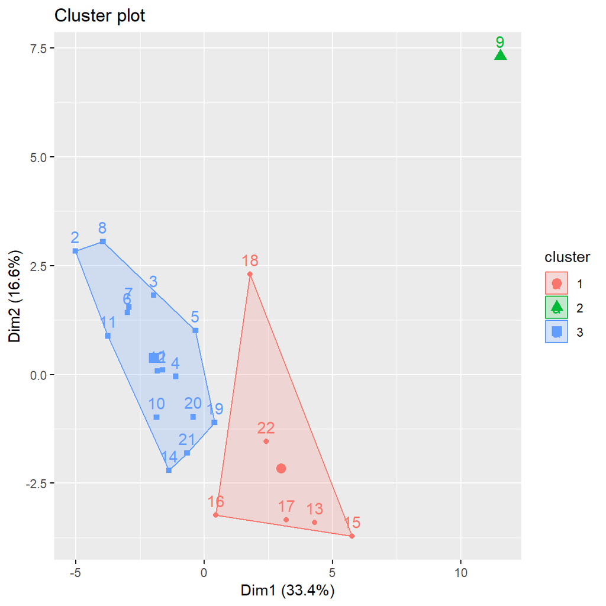

```r
fviz_cluster(final, data = scaled.school)
```

```r
numsum<- num.school %>%
  mutate(Cluster = final$cluster) %>%
  group_by(Cluster) %>%
  summarise_all("mean")

str(numsum)
```

```
## Classes 'tbl_df', 'tbl' and 'data.frame':    3 obs. of  45 variables:
##  $ Cluster         : int  1 2 3
##  $ school          : num  NA NA NA
##  $ eni             : num  0.751 0.507 0.804
##  $ pctELL          : num  0.0533 0 0.0873
##  $ pctAsian        : num  0.005 0.12 0.0127
##  $ pctBlack        : num  0.627 0.21 0.599
##  $ pctHispanic     : num  0.342 0.44 0.359
##  $ pctBlackHispanic: num  0.973 0.65 0.958
##  $ pctWhite        : num  0.00833 0.2 0.01267
##  $ pctAttend       : num  0.792 0.98 0.915
##  $ pctAbsentChronic: num  0.29 0.01 0.281
##  $ pctRigor        : num  0.907 0.87 0.863
##  $ pctCollab       : num  0.932 0.92 0.861
##  $ pctSupp         : num  0.848 0.88 0.837
```

[output cut: 31 more lines]

So based on our elbow and silhouette plots, we should either use 2 or 3 clusters, but based on our silhouette plot, the reality is with either choice, the low number of data points gives us clusters with weak to non-existent structure. Nonetheless, the analysis above does render some interesting information.

For the purpose of our analysis, we used 3 clusters (because there’s an interesting outlier as we can see), which explains about 41% of our variability. It’s not too bad given our limited data. So what did we find?

- Cluster 2 (Well Off Cluster)is distinct because it has a much lower ENI (wealthier), larger Asian and White population, no one learning ELL, higher attendance rates, higher test scores, higher academic scores, and perfect psychosocial ratings.
- Cluster 3 (Diverse Cluster) is distinct because it has the highest ENI of the three groups, lowest leadership and trust scores, lowest psychosocial ratings, lowest test scores, lowest number of 4s, and highest number of community schools.

### Recommendation 2.5

*Cluster 1 (Hi-Potential Cluster) is distinct because it has the highest number of URMs, lowest attendance rates, highest math scores for URMs, and most number of URM 4 scores. These schools represent a high diversity, high performance demographic as in many ways it replicates the performance of cluster 2, but the diversity and social needs of Cluster 3. While out of scope for this project, one recommendation for NYPASS is to find schools with similar characteristics of this school and invest their time and resources since it represents a school with high potential for increasing diversity in the SHSATs.

Now we will build a linear regression model that will predict turnout based on variables with high correlations, but first we will need to remove high correlation variables to prevent overfitting.

```r
#Linear model to predict the SHSAT test rates for other districts
correlation = cor(scaled.school)
hc = findCorrelation(correlation, cutoff=0.75)
hc = sort(hc)
reduced_Data = num.school[,-c(hc)]
print (reduced_Data)
```

```
## # A tibble: 22 x 21
##    school   eni pctBlackHispanic pctWhite pctAbsentChronic pctRigor
##    <chr>  <dbl>            <dbl>    <dbl>            <dbl>    <dbl>
##  1 P.S. ~ 0.903             0.97     0.01             0.39     0.91
##  2 P.S. ~ 0.835             0.93     0.04             0.49     0.83
##  3 P.S. ~ 0.854             0.93     0.01             0.33     0.9
##  4 EAGLE~ 0.747             0.98     0.01             0.47     0.92
##  5 P.S. ~ 0.875             0.95     0.01             0.35     0.89
##  6 URBAN~ 0.817             0.98     0.01             0.42     0.92
##  7 URBAN~ 0.817             0.98     0.01             0.42     0.92
##  8 KAPPA~ 0.852             0.92     0.01             0.35     0.77
##  9 COLUM~ 0.507             0.65     0.2              0.01     0.87
## 10 FREDE~ 0.708             0.94     0.02             0.22     0.89
## # ... with 12 more rows, and 15 more variables: pctCollab <dbl>,
## #   pctLeader <dbl>, avgMath <dbl>, elaAll4 <int>, mathAll <int>,
## #   mathAll4 <int>, mathHispanic <int>, quantCollab <dbl>,
## #   quantLeader <dbl>, pctELA4 <dbl>, pctELABlack <dbl>,
## #   pctELAWhite <dbl>, pctMathBlack <dbl>, URM4 <int>,
## #   commSchoolBinary <dbl>
```

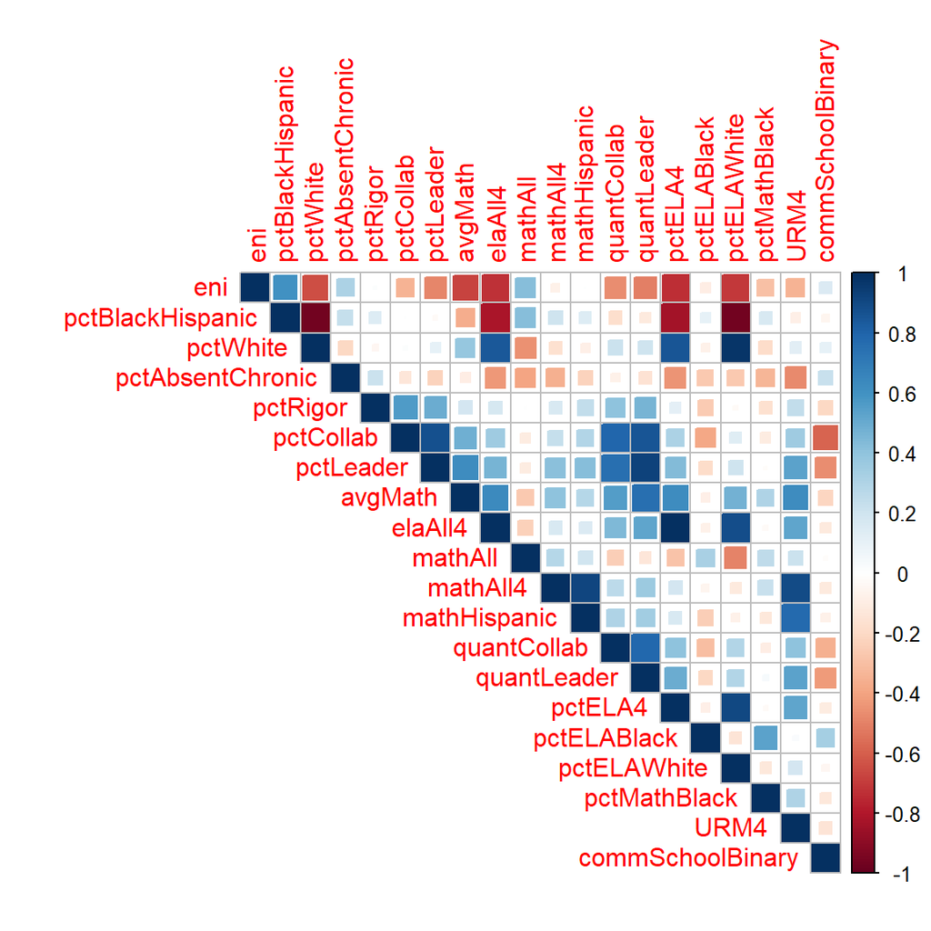

```r
corrplot(cor(reduced_Data[2:21]), type = "upper", method = "square")
```

```r
modelml <- lm(tookPct~ pctCommunity + pctAttend + elaAll ,data = num.school)
summary(modelml)
```

```
##
## Call:
## lm(formula = tookPct ~ pctCommunity + pctAttend + elaAll, data = num.school)
##
## Residuals:
##      Min       1Q   Median       3Q      Max
## -0.11503 -0.03116 -0.01832  0.04712  0.14657
##
## Coefficients:
##                Estimate Std. Error t value Pr(>|t|)
## (Intercept)  -0.3657533  0.4170979  -0.877   0.3921
## pctCommunity  0.8910628  0.4509004   1.976   0.0637 .
## pctAttend    -0.1304866  0.1200133  -1.087   0.2913
## elaAll       -0.0013360  0.0007842  -1.704   0.1056
## ---
## Signif. codes:  0 '***' 0.001 '**' 0.01 '*' 0.05 '.' 0.1 ' ' 1
##
## Residual standard error: 0.07017 on 18 degrees of freedom
## Multiple R-squared:  0.5661, Adjusted R-squared:  0.4938
## F-statistic: 7.827 on 3 and 18 DF,  p-value: 0.0015
```

```r
#new dataset with filled took %
schoolPredict <- school_clean %>%
  mutate(tookPct = predict(modelml, school_clean))%>%
  filter(!is.na(tookPct))%>%
  select(-income, -City, -address, -DBN, -registered, -yield, -took, -enroll,-regPct ,-commSchool, -school, -lat, -long, -zip, -district, -elaAsian, -mathAsian, -mathWhite, -pctELAAsian, -elaAsian, -pctCommunity, -pctAttend, -elaAll, -mathAll, -quantCommunity, -pctMathAsian, -pctMathWhite, -(contains("rating")))
```

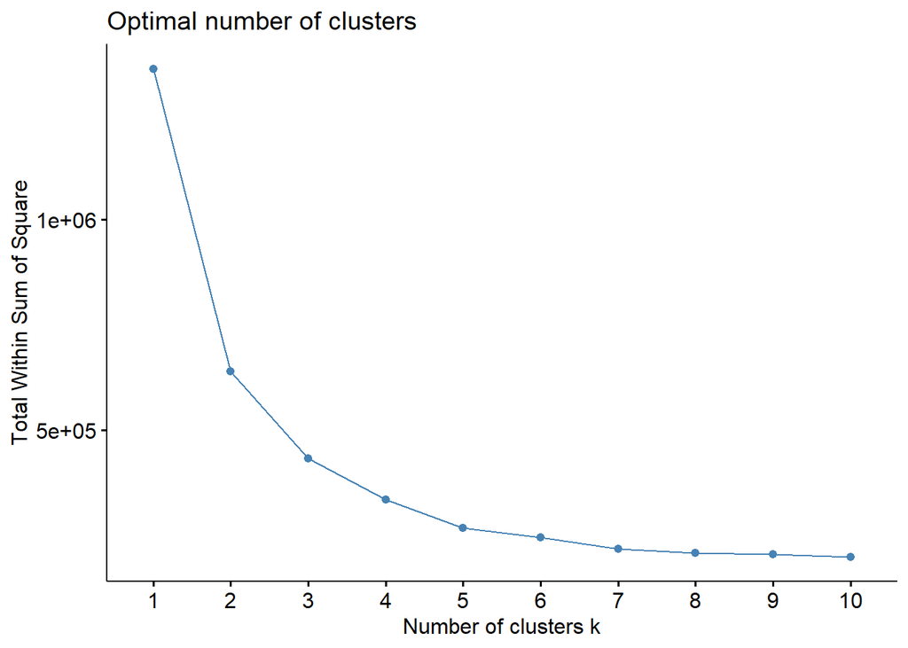

```r
#remove nzv
nzv_cols2 <- nearZeroVar(schoolPredict)
if(length(nzv_cols2) > 0) schoolPredict <- schoolPredict[, -nzv_cols2]

#elbow and silhouette
schoolPredictClust<- schoolPredict%>% select(-tookPct)
fviz_nbclust(schoolPredictClust, kmeans, method = "wss")
```

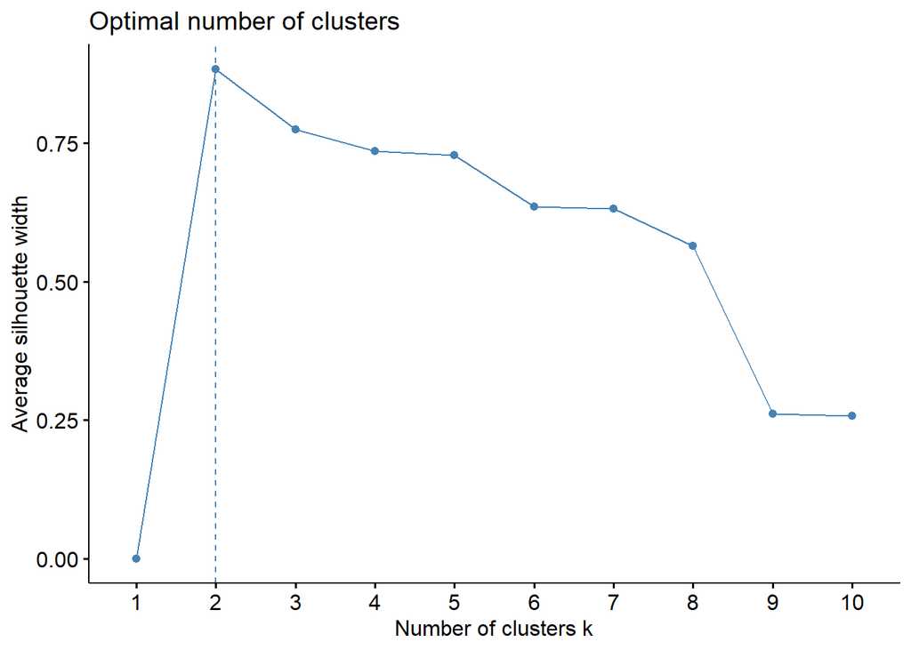

```r
fviz_nbclust(schoolPredictClust, kmeans, method = "silhouette")
```

```r
final2 <- kmeans(schoolPredictClust, 2, nstart = 25)
print(final2)
```

```
## K-means clustering with 2 clusters of sizes 37, 1211
##
## Cluster means:
##         eni     pctELL  pctAsian   pctBlack pctHispanic pctBlackHispanic
## 1 0.4505405 0.08189189 0.3267568 0.08027027   0.2527027        0.3332432
## 2 0.6791751 0.12686210 0.1111561 0.32584641   0.4173823        0.7431627
##    pctWhite pctAbsentChronic  pctRigor pctCollab   pctSupp pctLeader
## 1 0.3259459        0.1256757 0.8856757 0.8881081 0.8551351 0.8294595
## 2 0.1251280        0.2186705 0.8950702 0.8842279 0.8884806 0.8156978
##    pctTrust   avgELA  avgMath    elaAll4  elaBlack elaHispanic  mathAll4
## 1 0.9008108 3.024054 3.252973 103.513514 4.2972973   13.594595 96.756757
## 2 0.9042940 2.518899 2.650479   4.528489 0.8315442    1.181668  2.203138
##   mathHispanic academicScore quantRigor quantCollab quantSupp quantLeader
## 1   11.5675676      6.277027   3.405405    3.594595  3.162162    2.891892
## 2    0.6416185      5.169378   2.848059    3.032205  2.902560    2.770438
```

[output cut: 55 more lines]

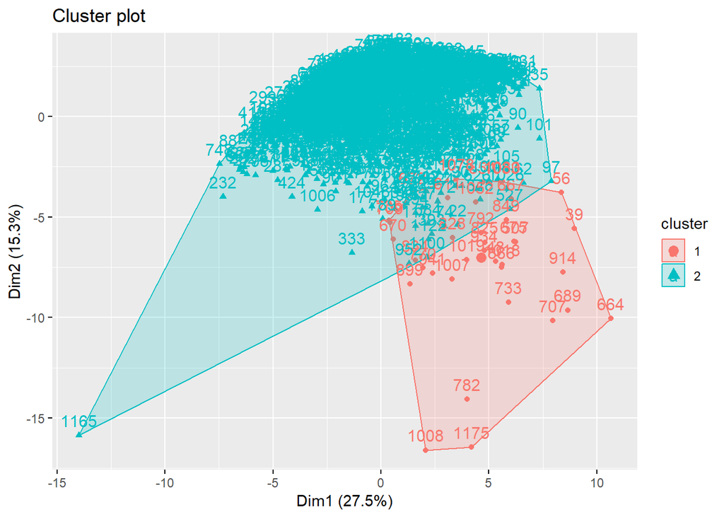

```r
fviz_cluster(final2, data = schoolPredictClust)
```

```r
#clustering
schoolPredictSum<- schoolPredictClust%>%
  mutate(Cluster = final2$cluster) %>%
  group_by(Cluster) %>%
  summarise_all("mean")

str(schoolPredictSum)
```

```
## Classes 'tbl_df', 'tbl' and 'data.frame':    2 obs. of  32 variables:
##  $ Cluster         : int  1 2
##  $ eni             : num  0.451 0.679
##  $ pctELL          : num  0.0819 0.1269
##  $ pctAsian        : num  0.327 0.111
##  $ pctBlack        : num  0.0803 0.3258
##  $ pctHispanic     : num  0.253 0.417
##  $ pctBlackHispanic: num  0.333 0.743
##  $ pctWhite        : num  0.326 0.125
##  $ pctAbsentChronic: num  0.126 0.219
##  $ pctRigor        : num  0.886 0.895
##  $ pctCollab       : num  0.888 0.884
##  $ pctSupp         : num  0.855 0.888
##  $ pctLeader       : num  0.829 0.816
##  $ pctTrust        : num  0.901 0.904
```

[output cut: 18 more lines]

Cluster 1 (Well-Off) has a lower ENI, larger white and Asian population, lower chronic absenteeism, substantially more 4s and URM 4 scores despite there being less of them in the district.

Clust 2 (High Need) has a higher ENI, about double the URM population and absentee rates of the Well-Off cluster, very low number of 4 scores, and many community schools.